# ME415 Latent Variable Modelling and Structual Equation Modelling for Social Science Research

Shea Zhao

August 28, 2017

## Description

This document is the final project for the LSE **ME415** Summer Methods Programme course. Below is the R I used as well as a step-by-step analysis of the output.

## Load data

```r
# import & explore data
library(foreign)
library(haven)

physfunc <- read_dta("~/Desktop/physfunc.dta")
View(physfunc)
```

## Explore the data

```r
str(physfunc)
colnames(physfunc)
    # "id"   "occ"  "female" "grade"  "age50"  "phf"
unique(physfunc$occ) # 6 measurement periods
sum(is.na(physfunc)) # there are 18189 NA's in this dataset
summary(physfunc)
    # females make-up about 31% of participants
    # mean age is 6.647 & median age is 6.621
    # mean phf is 50.284 & median is 52. 620
```

## Tidy data before moving on to questions

The aim of this exercise is to investigate the following questions: How does women’s physical functioning change as they get older? To what extent does this vary between women?

So we can create a new dataframe with just women in it.

```r
# create a new data frame with just women
library(magrittr)
library(tidyverse)
library(reshape2)

Women <- physfunc %>%
    filter(female == 1) %>%
    na.omit()

View(Women) # only 12451 objects in "Women" data frame
```

I no longer need the gender column, so I removed it and the NAs

```r
Women_2 <- Women %>%
    select(-female) %>%
    na.omit()

head(Women_2)
    # A tibble: 6 x 5
    # id   occ     grade    age50      phf
    # <dbl> <dbl> <dbl+lbl>    <dbl>    <dbl>
    # 1     1     1         2  5.00000 39.59072
    # 2     1     2         2  7.00000 38.61111
    # 3     1     3         2 10.41615 39.92796
    # 4     1     4         2 13.64844 21.91010
    # 5     1     5         2 16.62012 25.65662
    # 6     2     1         3  6.00000 29.31145
```

## Questions

### 1) Obtain summary statistics for phf and age50 at each occasion.

Wrote function to view only the summary statistics that I care about

```r
install.packages("lavaan")
library(lavaan)
library(reshape2)

multi.fun <- function(x) {
    c(mean = mean(x), median = median(x), sd = sd(x), var = var(x), min = min(x),
      max = max(x), range = range(x), quantile = quantile(x))
}
```

```r
occ_1 <- Women_2 %>%
    filter(occ == "1") %>%
    select(-id, -occ, - grade) %>%
    sapply(multi.fun)

occ_1
    # age50       phf
    # mean            0.3386656 49.856628
    # median          0.0000000 52.082150
    # sd              6.1466605  8.897158
    # var            37.7814357 79.159415
    # min           -11.0000000  6.407695
    # max            13.0000000 71.575737
    # range1        -11.0000000  6.407695
    # range2         13.0000000 71.575737
    # quantile.0%   -11.0000000  6.407695
    # quantile.25%   -5.0000000 45.881485
    # quantile.50%    0.0000000 52.082150
    # quantile.75%    6.0000000 56.098101
    # quantile.100%  13.0000000 71.575737

occ_2 <- Women_2 %>%
    filter(occ == "2") %>%
    select(-id, -occ, - grade) %>%
    sapply(multi.fun)

occ_2
    # age50       phf
    # mean           3.392399 48.529781
    # median         3.000000 51.318520
    # sd             6.165760  9.902452
    # var           38.016600 98.058552
    # min           -8.000000 11.804350
    # max           15.000000 69.590912
    # range1        -8.000000 11.804350
    # range2        15.000000 69.590912
    # quantile.0%   -8.000000 11.804350
    # quantile.25%  -2.000000 43.620581
    # quantile.50%   3.000000 51.318520
    # quantile.75%   9.000000 55.685865
    # quantile.100% 15.000000 69.590912

occ_3 <- Women_2 %>%
    filter(occ == "3") %>%
    select(-id, -occ, - grade) %>%
    sapply(multi.fun)

occ_3
    # age50       phf
    # mean           6.2109378 48.512209
    # median         5.7262149 51.035210
    # sd             6.0263640  9.809208
    # var           36.3170625 96.220564
    # min           -4.7871318 11.473180
    # max           18.4462700 69.627800
    # range1        -4.7871318 11.473180
    # range2        18.4462700 69.627800
    # quantile.0%   -4.7871318 11.473180
    # quantile.25%   0.9404526 43.701321
    # quantile.50%   5.7262149 51.035210
    # quantile.75%  11.6427097 55.430580
    # quantile.100% 18.4462700 69.627800

occ_4 <- Women_2 %>%
    filter(occ == "4") %>%
    select(-id, -occ, - grade) %>%
    sapply(multi.fun)

occ_4
    # age50        phf
    # mean           9.539228  47.856429
    # median         9.226563  51.137680
    # sd             6.175221  10.397208
    # var           38.133359 108.101933
    # min           -1.640625   9.355224
    # max           21.078131  69.819252
    # range1        -1.640625   9.355224
    # range2        21.078131  69.819252
    # quantile.0%   -1.640625   9.355224
    # quantile.25%   4.054688  41.924149
    # quantile.50%   9.226563  51.137680
    # quantile.75%  15.140630  55.367470
    # quantile.100% 21.078131  69.819252

occ_5 <- Women_2 %>%
    filter(occ == "5") %>%
    select(-id, -occ, - grade) %>%
    sapply(multi.fun)

occ_5
    # age50       phf
    # mean          11.5588791  46.20331
    # median        11.0362802  49.27971
    # sd             6.1255685  10.64468
    # var           37.5225888 113.30925
    # min            0.4668045  11.32698
    # max           24.0807590  71.85617
    # range1         0.4668045  11.32698
    # range2        24.0807590  71.85617
    # quantile.0%    0.4668045  11.32698
    # quantile.25%   6.2402475  40.15645
    # quantile.50%  11.0362802  49.27971
    # quantile.75%  17.0561218  54.04741
    # quantile.100% 24.0807590  71.85617
occ_6 <- Women_2 %>%
    filter(occ == "6") %>%
    select(-id, -occ, - grade) %>%
    sapply(multi.fun)

occ_6
    # age50       phf
    # mean          14.3613935  46.84055
    # median        13.8984404  50.37339
    # sd             6.0563290  10.59076
    # var           36.6791210 112.16416
    # min            0.3046875  11.38633
    # max           26.5000000  70.09693
    # range1         0.3046875  11.38633
    # range2        26.5000000  70.09693
    # quantile.0%    0.3046875  11.38633
    # quantile.25%   9.1210942  40.46995
    # quantile.50%  13.8984404  50.37339
    # quantile.75%  19.7031307  54.71719
    # quantile.100% 26.5000000  70.09693
    # mean age increases and mean phf decreases over time
```

exploratory plots as expected age increases by occ, and phf decreases slightly TRY TO MAKE GRADE 3RD DIM

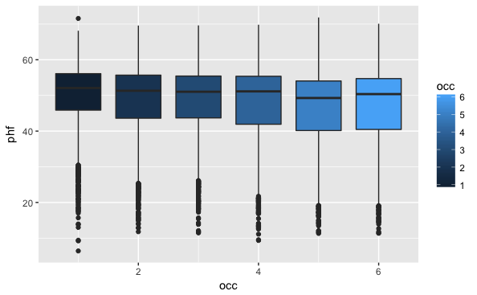

```r
library(ggplot2)
library(knitr)
getwd()

occ_phf.plot <- ggplot(Women_2, aes(x = occ, y = phf, group = occ, fill = occ)) + geom_boxplot() # fit a line?
occ_phf.plot
```

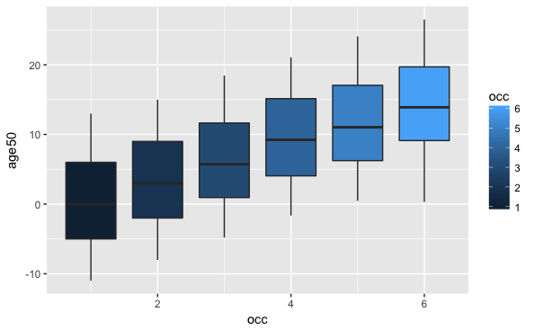

```r
occ_age.plot <- ggplot(Women_2, aes(x = occ, y = age50, group = occ, fill = occ)) +
    geom_boxplot() # fit a line?
occ_age.plot
```

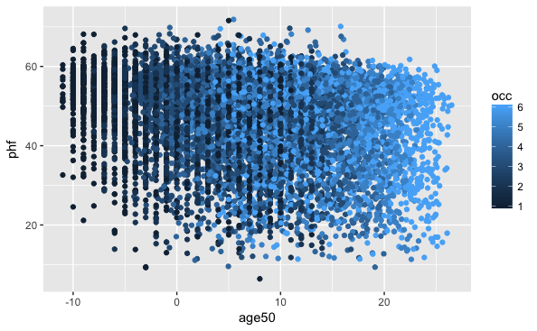

```r
age_phf.plot <- ggplot(Women_2, aes(x = age50, y = phf, color = occ, fill = occ)) +
    geom_point() # fit a line?
age_phf.plot
```

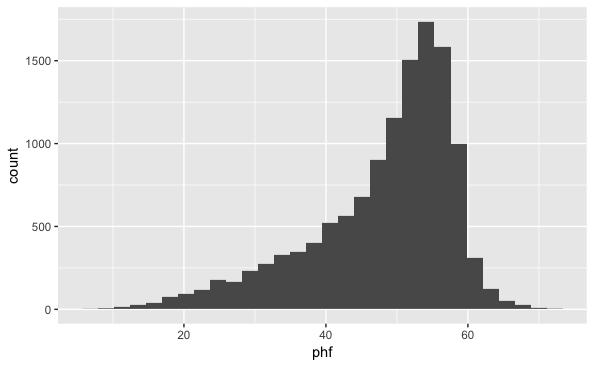

```r
phf_hist <- ggplot(Women_2, aes(phf)) + geom_histogram()
```

```r
age_hist <- ggplot(Women_2, aes(age50)) + geom_histogram()
```

[output not shown]

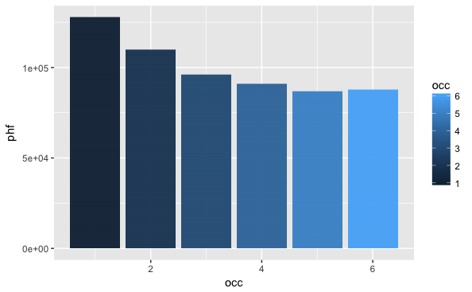

```r
bargraph <- ggplot(Women_2, aes(x = occ, y = phf, fill = occ)) + geom_bar(stat = "identity")
```

```r
ggplot(Women_2, aes(x = grade, y = phf)) + geom_violin()
```

[output not shown]

### 2) Plot physical functioning trajectories by age for the first 5 individuals in the dataset

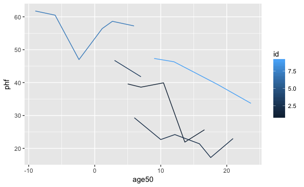

```r
first_5 <- Women_2[Women_2$id < 14, ]
View(first_5)

F5.plot <- ggplot(first_5, aes(x=age50, y=phf, group = id, colour = id)) +
    geom_line()
    # generally, as age increases physical function is very decreasing
```

### 3) Fit a simple random effects model for phf with no explanatory variables (i.e. only the constant term). What is the intra-individual correlation?

```r
install.packages("lme4")
install.packages("arm")
library(lme4)
library(arm)

    # think of individual as the random variable because phf and age varies
    # differently from person-to-person over time

# fit model with a random intercept (individual represented by id number in the dataset)
model_1 <- lmer(phf ~ (1 | id), data = Women_2, REML = FALSE)
summary(model_1)

        # Linear mixed model fit by maximum likelihood  ['lmerMod']
        # Formula: phf ~ (1 | id)
        # Data: Women_2
        #
        # AIC      BIC   logLik deviance df.resid
        # 87077.6  87099.9 -43535.8  87071.6    12448
        #
        # Scaled residuals:
        #     Min      1Q  Median      3Q     Max
        # -4.6796 -0.4190  0.1098  0.5159  3.9693
        #
        # Random effects:
        #     Groups   Name        Variance Std.Dev.
        # id       (Intercept) 61.2     7.823
        # Residual             41.5     6.442
        # Number of obs: 12451, groups:  id, 2697
        #
        # Fixed effects:
        #     Estimate Std. Error t value
        # (Intercept)  47.8880     0.1637   292.6
```

### 4) Fit a random intercepts growth model which allows an individual’s physical functioning to change linearly with age.

```r
#Fitting the  model with the random intercept
model_2 <- lmer(phf ~ age50+(1 | id), data = Women_2, REML = FALSE)
summary(model_2)

        # Linear mixed model fit by maximum likelihood  ['lmerMod']
        # Formula: phf ~ age50 + (1 | id)
        # Data: Women_2
        #
        # AIC      BIC   logLik deviance df.resid
        # 86467.5  86497.2 -43229.8  86459.5    12447
        #
        # Scaled residuals:
        #     Min      1Q  Median      3Q     Max
        # -4.5153 -0.4393  0.1078  0.5267  3.7917
        #
        # Random effects:
        #     Groups   Name        Variance Std.Dev.
        # id       (Intercept) 58.81    7.669
        # Residual             39.43    6.279
        # Number of obs: 12451, groups:  id, 2697
        #
        # Fixed effects:
        #     Estimate Std. Error t value
        # (Intercept)  49.6852     0.1757  282.86
        # age50        -0.2655     0.0106  -25.05
        #
        # Correlation of Fixed Effects:
        #     (Intr)
        # age50 -0.409
```

### 5) Fit a random slopes model that allows the rate of change in physical functioning to vary among individuals.

```r
Fitting the  model with the random intercept and random slope
model_3 <- lmer(phf ~ age50+(1 | id) + (0 + age50 | id), data = Women_2, REML = FALSE)
summary(model_3)

        # Linear mixed model fit by maximum likelihood  ['lmerMod']
        # Formula: phf ~ age50 + (1 | id) + (0 + age50 | id)
        # Data: Women_2
        #
        # AIC      BIC   logLik deviance df.resid
        # 86152.7  86189.8 -43071.3  86142.7    12446
        #
        # Scaled residuals:
        #     Min      1Q  Median      3Q     Max
        # -4.3785 -0.4142  0.1063  0.5026  3.5006
        #
        # Random effects:
        #     Groups   Name        Variance Std.Dev.
        # id       (Intercept) 51.2462  7.1586
        # id.1     age50        0.1395  0.3735
        # Residual             34.8499  5.9034
        # Number of obs: 12451, groups:  id, 2697
        #
        # Fixed effects:
        #     Estimate Std. Error t value
        # (Intercept) 49.83138    0.16725  297.95
        # age50       -0.26557    0.01272  -20.88
        #
        # Correlation of Fixed Effects:
        #     (Intr)
        # age50 -0.319
```

### 6) Carry out a likelihood ratio test of the null hypothesis that growth rate is fixed across individuals.

```r
# As I understand, to do a likelihood ratio test, I must compare two models
# I'm comparing two models - model_1 and model_2

anova(model_1, model_2)

    # Data: Women_2
    # Models:
    #     model_1: phf ~ (1 | id)
    # model_2: phf ~ age50 + (1 | id)
    # Df   AIC   BIC logLik deviance  Chisq Chi Df Pr(>Chisq)
    # model_1  3 87078 87100 -43536    87072
    # model_2  4 86468 86497 -43230    86460 612.09      1  < 2.2e-16 ***
    #     ---
    #     Signif. codes:  0 ‘***’ 0.001 ‘**’ 0.01 ‘*’ 0.05 ‘.’ 0.1 ‘ ’ 1
```

### 7) Produce a plot of that superimposes predicted phf trajectories from the random intercepts and random slopes models and the observed values of phf for the first 5 individuals.

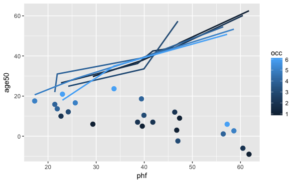

```r
# initially I made this model, but I could not figure out how to plot it
model_3 <- lmer(phf ~ age50+(1 | id) + (0 + age50 | id), data = Women_2, REML = FALSE)
summary(model_3)

first_5 <- Women_2[Women_2$id < 14, ]
View(first_5)

# could not figure out how to plot only first five women without taking other women out the model - I'm sure this is not right, but the plot works

model_3.2 <- lmer(phf ~ age50+(1 | id) + (0 + age50 | id), data = first_5, REML = FALSE)
summary(model_3.2)

    # Linear mixed model fit by maximum likelihood  ['lmerMod']
    # Formula: phf ~ age50 + (1 | id) + (0 + age50 | id)
    # Data: first_5
    #
    # AIC      BIC   logLik deviance df.resid
    # 158.5    164.2    -74.3    148.5       18
    #
    # Scaled residuals:
    #     Min       1Q   Median       3Q      Max
    # -2.26059 -0.22275  0.07196  0.44317  1.41303
    #
    # Random effects:
    #     Groups   Name        Variance Std.Dev.
    # id       (Intercept) 64.99    8.061
    # id.1     age50        0.00    0.000
    # Residual             20.90    4.572
    # Number of obs: 23, groups:  id, 5
    #
    # Fixed effects:
    #     Estimate Std. Error t value
    # (Intercept)  46.6377     4.0977  11.382
    # age50        -0.7863     0.1881  -4.181
    #
    # Correlation of Fixed Effects:
    #     (Intr)
    # age50 -0.404

library(ggplot2)
F5_2 <- ggplot(first_5, aes(x = phf, y = age50, group = occ, color = occ)) +
    geom_point(size=3) +
    geom_line(aes(y = predict(model_3.2)),size = 1)
print(F5_2)
```

### 8) Fit a quadratic growth model with a fixed coefficient for age-squared. (A model with a random coefficient for age-squared fails to converge.)

```r
install.packages("nlme")
library(nlme)

model_4 <- lme(phf ~ age50 + I (age50^2), random =~ age50 | id, data = Women_2)
summary(model_4)

        # Linear mixed-effects model fit by REML
        # Data: Women_2
        # AIC      BIC    logLik
        # 86134.25 86186.26 -43060.13
        #
        # Random effects:
        #     Formula: ~age50 | id
        # Structure: General positive-definite, Log-Cholesky parametrization
        # StdDev    Corr
        # (Intercept) 7.0762752 (Intr)
        # age50       0.3576407 0.063
        # Residual    5.9142383
        #
        # Fixed effects: phf ~ age50 + I(age50^2)
        # Value  Std.Error   DF   t-value p-value
        # (Intercept) 49.80392 0.16548872 9752 300.95055       0
        # age50       -0.18133 0.01802704 9752 -10.05856       0
        # I(age50^2)  -0.00643 0.00099026 9752  -6.48870       0
        # Correlation:
        #     (Intr) age50
        # age50      -0.214
        # I(age50^2)  0.012 -0.719
        #
        # Standardized Within-Group Residuals:
        #     Min         Q1        Med         Q3        Max
        # -4.3644586 -0.4121647  0.1068419  0.5024621  3.4697630
        #
        # Number of Observations: 12451
        # Number of Groups: 2697



# Compare this model to the linear growth model using a likelihood ratio test.

# in order to compare model_3 and model_4

model_3.2 <- lme(phf ~ age50, random =~ age50 | id, data = Women_2)
summary(model_3.2)

        # Linear mixed-effects model fit by REML
        # Data: Women_2
        # AIC      BIC    logLik
        # 86162.1 86206.68 -43075.05
        #
        # Random effects:
        #     Formula: ~age50 | id
        # Structure: General positive-definite, Log-Cholesky parametrization
        # StdDev    Corr
        # (Intercept) 7.0854582 (Intr)
        # age50       0.3650564 0.053
        # Residual    5.9161572
        #
        # Fixed effects: phf ~ age50
        # Value  Std.Error   DF   t-value p-value
        # (Intercept) 49.82151 0.16577436 9753 300.53813       0
        # age50       -0.26546 0.01262867 9753 -21.02015       0
        # Correlation:
        #     (Intr)
        # age50 -0.298
        #
        # Standardized Within-Group Residuals:
        #     Min         Q1        Med         Q3        Max
        # -4.3825737 -0.4152879  0.1058552  0.5025557  3.5242316
        #
        # Number of Observations: 12451
        # Number of Groups: 2697

anova(model_4, model_3.2)

        # Model df      AIC      BIC    logLik   Test  L.Ratio p-value
        # model_4       1  7 86134.25 86186.26 -43060.13
        # model_3.2     2  6 86162.10 86206.68 -43075.05 1 vs 2 29.84889  <.0001
        # Warning message:
        #     In anova.lme(model_4, model_3.2) :
        #     fitted objects with different fixed effects. REML comparisons are not meaningful.
```